# Tarea 7

## Parte 1

Resuelve el ejercicio 7.1.0.1 de las notas (sigue el ejemplo anterior a este ejercicio). Puedes utilizar nnet o el código con el que optimizamos en clase.

Este es el código para generar los datos:

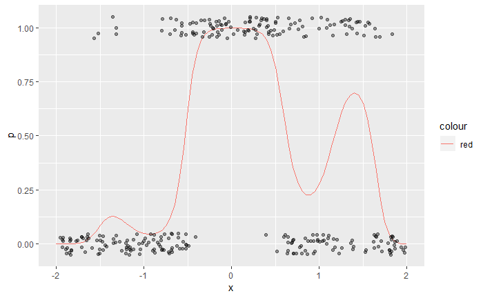

```r
library(tidyverse)
h <- function(x){
    exp(x)/(1 + exp(x))
}
x <- seq(-2,2,0.05)
p <- h(3 + x- 3 * x ^ 2 + 3 * cos(4 * x))
set.seed(100)
x.2 <- runif(300, -2, 2)
g.2 <- rbinom(300, 1, h(3 + x.2 - 3 * x.2 ^ 2 + 3 * cos(4 * x.2)))
datos <- data.frame(x.2,g.2)
dat.p <- data.frame(x,p)
g <- qplot(x,p, geom='line', col='red')
g + geom_jitter(data = datos, aes(x=x.2,y=g.2), col ='black',
  position =position_jitter(height=0.05), alpha=0.4)
```

```r
feed_fow <- function(beta, x){
  a_1 <- h(beta[1] + beta[2] * x) # calcula variable 1 de capa oculta
  a_2 <- h(beta[3] + beta[4] * x) # calcula variable 2 de capa oculta
  a_3 <- h(beta[5] + beta[6] * x) # calcula variable 2 de capa oculta
  a_4 <- h(beta[7] + beta[8] * x) # calcula variable 2 de capa oculta
  p <- h(beta[9] + beta[10]*a_1 + beta[11]*a_2 + beta[12]*a_3 + beta[13]*a_4) # calcula capa de salida
  p
}
```

```r
devianza_fun <- function(x, y){
    # esta función es una fábrica de funciones
   devianza <- function(beta){
         p <- feed_fow(beta, x)
      - 2 * mean(y*log(p) + (1-y)*log(1-p))
   }
  devianza
}
```

```r
dev <- devianza_fun(x.2,g.2)
dev(c(0,0,0,0,0,0,0,0,0,0,0,0,0))
```

```
[1] 1.386294
```

```r
set.seed(5)
salida <- optim(rnorm(13), dev, method = 'BFGS') # inicializar al azar punto inicial
salida
```

```
$par
 [1]  -3.493032  10.260764  -2.259653  -3.842720   4.649641   7.041095  -7.366407
 [8] -21.633988   5.095310  -9.988444   1.245950   4.219821  -8.915593

$value
[1] 0.8452337

$counts
function gradient
     100      100

$convergence
[1] 1

$message
NULL
```

```r
beta <- salida$par
beta
```

```
 [1]  -3.493032  10.260764  -2.259653  -3.842720   4.649641   7.041095  -7.366407
 [8] -21.633988   5.095310  -9.988444   1.245950   4.219821  -8.915593
```

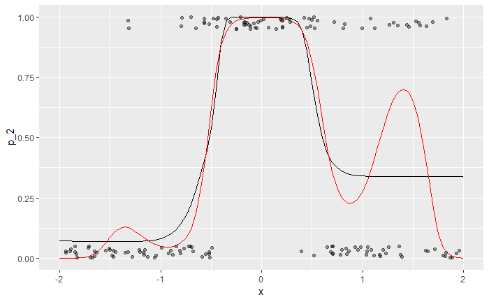

```r
## hacer feed forward con beta encontrados
p_2 <- feed_fow(beta, x)
dat_2 <- data.frame(x, p_2 = p_2)
ggplot(dat_2, aes(x = x, y = p_2)) + geom_line() +
geom_line(data = dat.p, aes(x = x, y = p), col='red') +ylim(c(0,1))+
   geom_jitter(data = datos, aes(x=x.2,y=g.2), col ='black',
    position =position_jitter(height=0.05), alpha=0.4)
```

- ¿Qué tan bien puedes recuperar la forma verdadera (la función $p$, o la curva roja en la gráfica)?
- ¿Cuántas variables derivadas $a_k$ utilizaste? Intenta usar el mínimo posible.
- A grandes rasgos, ¿puedes capturar todos los movimientos de la función verdadera $p$ con esta muestra de entrenamiento? Explica por qué si puedes o por qué no.

## Parte 2

1. Instala el paquete keras de R en tu computadora. Sigue [estas instrucciones](https://keras.rstudio.com).
2. **Si no funciona el método de arriba en tu computadora** (generalmente por instalaciones de python diferentes, etc), puedes instalar en un contenedor de docker.

Primero instala [docker](https://www.docker.com/get-started) en tu computadora. Baja el archivo Dockerfile del repositorio (se tiene que llamar Dockerfile, sin extensión). En línea de comandos, en el mismo directorio donde está el Dockerfile, corre las siguiente línea:

```
docker build -t aprendizaje-rstudio .
```

Esto va a tomar varios minutos, pero solo hay que correrlo una vez.

Después, cuando quieras usar el contenedor, corre:

```
docker run --rm -p 8787:8787 -e PASSWORD=tupassword -v ~/tu/carpeta/local:/home/rstudio/ aprendizaje-rstudio
```

Nota: en windows la segunda línea debe ser de la forma:

```
docker run --rm -p 8787:8787 -e PASSWORD=tupassword -v /c/Users/miusuario/micarpeta:/home/rstudio/ aprendizaje-rstudio
```

Y abre en Chrome o Safari (o el navegador que uses) la dirección:

http://localhost:8787

Y ahora puedes trabajar en rstudio dentro del contenedor de docker (user: rstudio, password: tupassword).

3. Corre algún ejemplo para checar tu instalación, por ejemplo:

https://keras.rstudio.com/articles/tutorial_basic_regression.html